# Анализ данных, связанных с баскетбольными игроками NBA

**Квантили:**

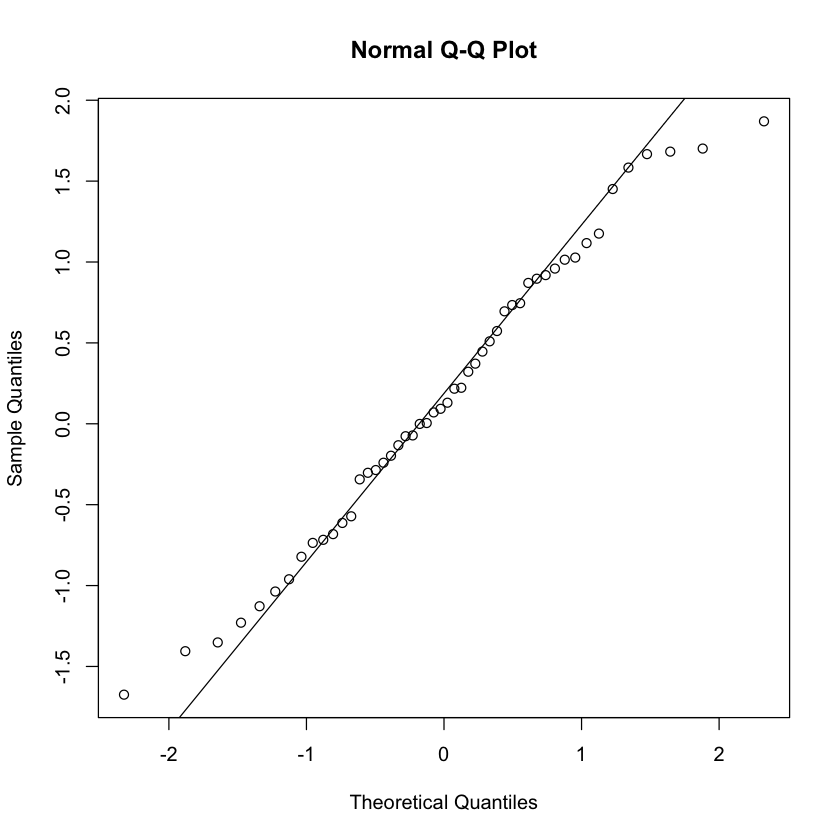

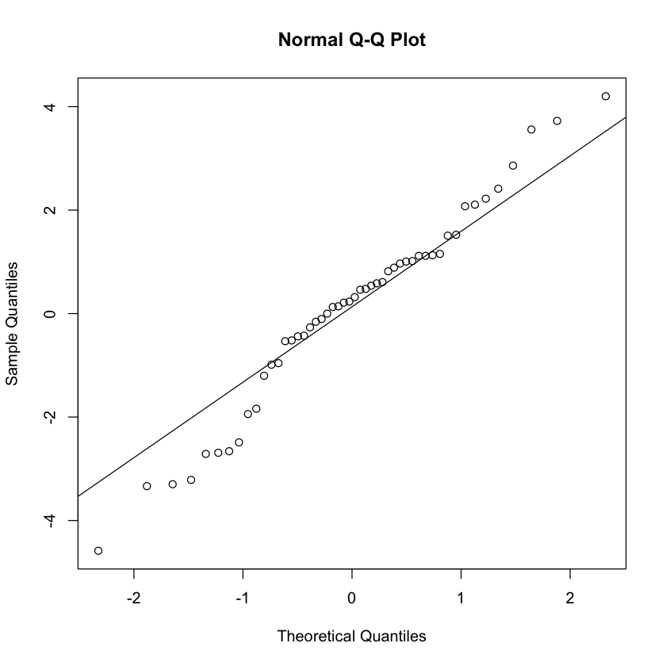

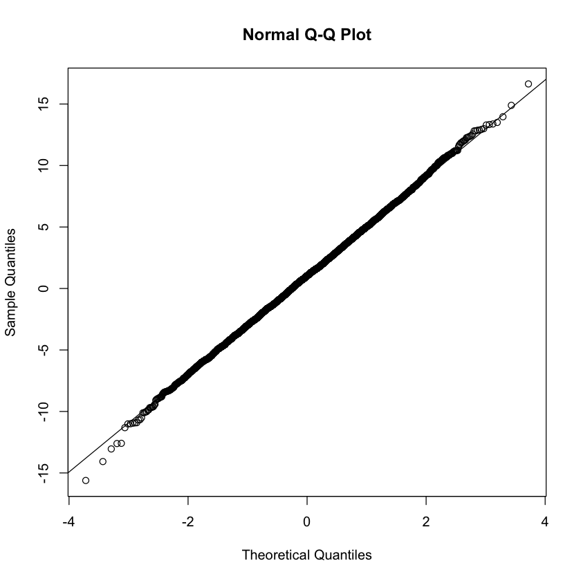

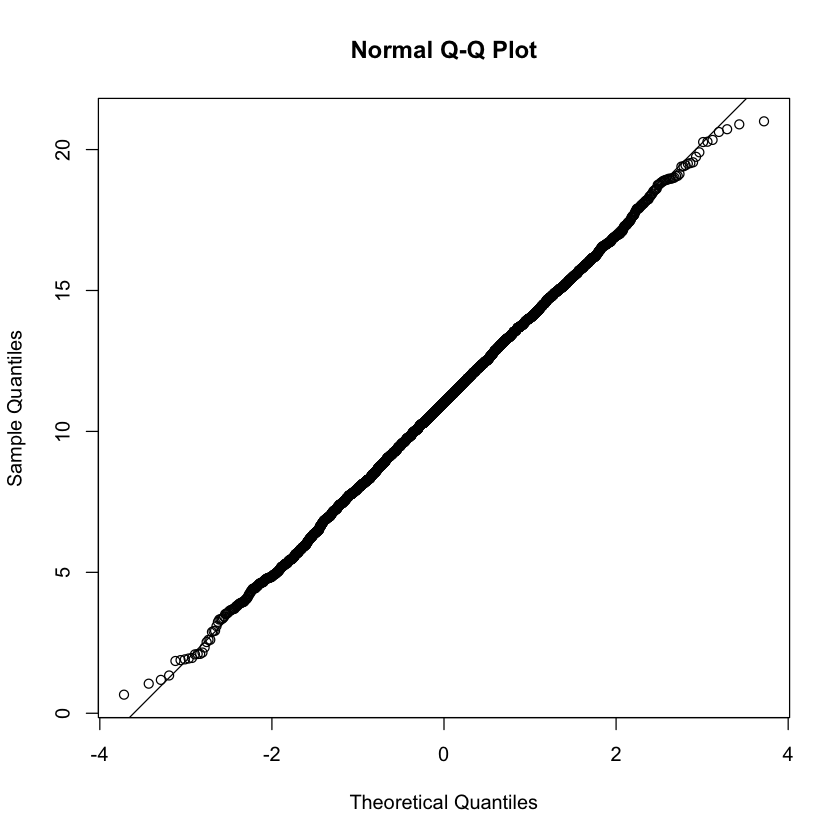

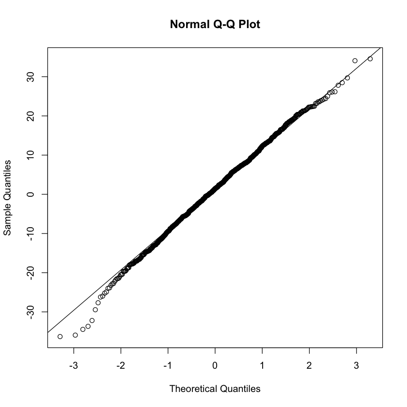

```r
# R
qqgraph <- function(x){
  qqnorm(x)
  qqline(x)
}

qqgraph(data1)
qqgraph(data2)
qqgraph(data3)
qqgraph(data4)
qqgraph(data5)
```

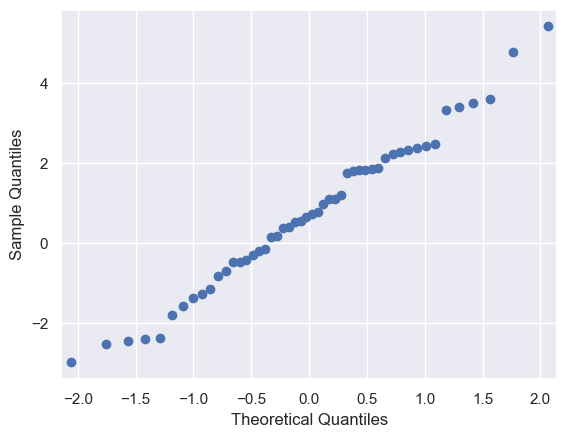

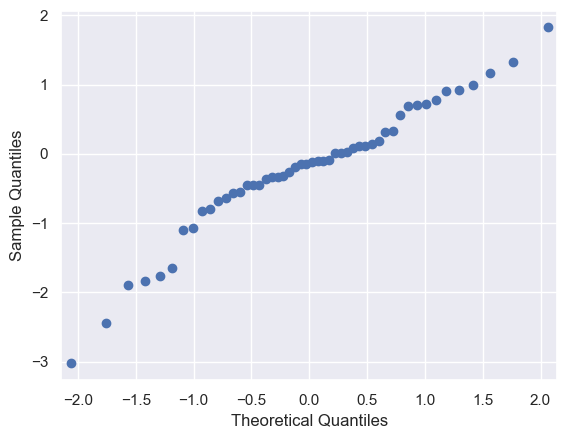

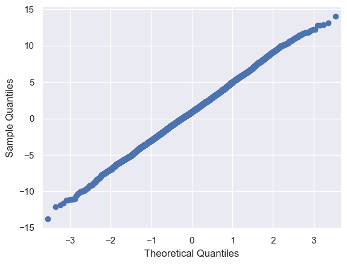

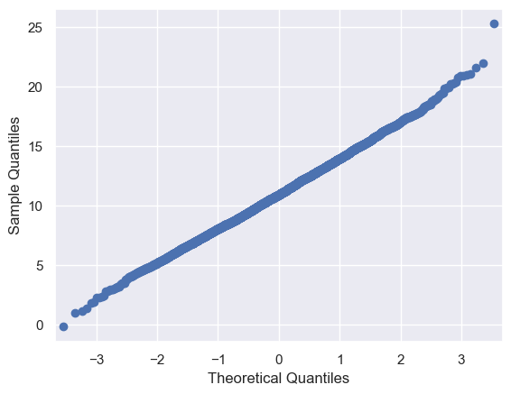

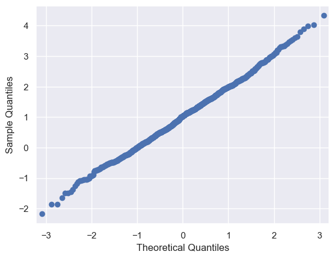

```r
# Python
import statsmodels.api as sm

sm.qqplot(data1)
sm.qqplot(data2)
sm.qqplot(data3)
sm.qqplot(data4)
sm.qqplot(data5)


plt.show()
```

**Метод огибающих:**

**Примечание:** реализацию метода огибающих нашла только на R

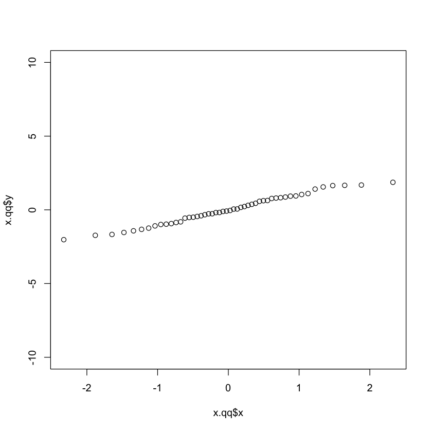

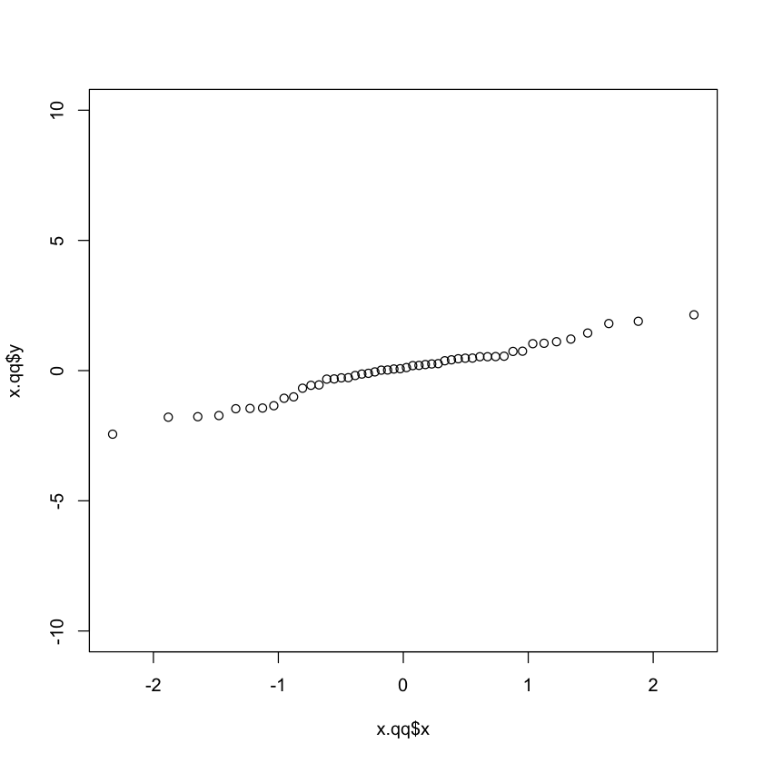

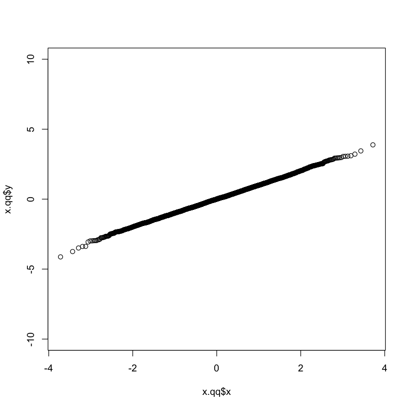

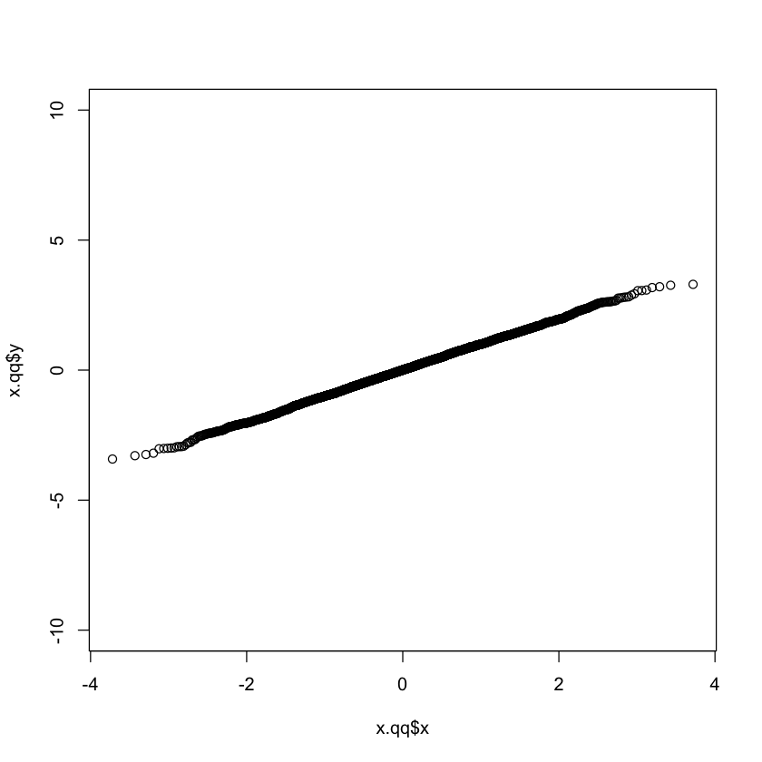

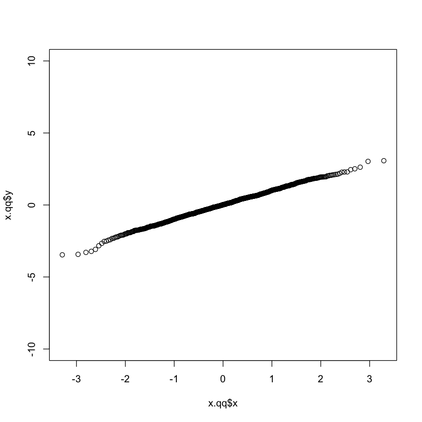

```r
# R
envelmet <- function(x){
  z <- (x - mean(x))/sqrt(var(x))  #  Стандартизация выборки
  x.qq <- qqnorm(z, plot.it = FALSE)
  x.qq <- lapply(x.qq, sort)
  plot(x.qq, ylim = c(-10, 10))
}

envelmet(data1)
envelmet(data2)
envelmet(data3)
envelmet(data4)
envelmet(data5)
```

**Стандартные процедуры проверки гипотез о нормальности:**

**Критерий Колмогорова-Смирнова:**

```r
# Python
from scipy.stats import kstest

print("1: ", kstest(data1, 'norm'))
print("2: ", kstest(data2, 'norm'))
print("3: ", kstest(data3, 'norm'))
print("4: ", kstest(data4, 'norm'))
print("5: ", kstest(data5, 'norm'))
```

```
1:  KstestResult(statistic=0.34007438841765414, pvalue=1.1553092842054505e-05)
2:  KstestResult(statistic=0.16799106944576814, pvalue=0.10571279449866022)
3:  KstestResult(statistic=0.3747439141989374, pvalue=0.0)
4:  KstestResult(statistic=0.9958940595585472, pvalue=0.0)
5:  KstestResult(statistic=0.3855813341290513, pvalue=2.7227082855966367e-134)
```

Одновыборный тест Колмогорова-Смирнова:

```r
# R
ks.test(data1, "pnorm")
ks.test(data5, "pnorm")
```

```
	Exact one-sample Kolmogorov-Smirnov test

data:  data1
D = 0.27548, p-value = 0.0007605
alternative hypothesis: two-sided
```

```
	Asymptotic one-sample Kolmogorov-Smirnov test

data:  data5
D = 0.44097, p-value < 2.2e-16
alternative hypothesis: two-sided
```

Двухвыборный тест Колмогорова-Смирнова:

```r
# R
ks.test(data1, data3)
ks.test(data4, data5)
```

```
	Asymptotic two-sample Kolmogorov-Smirnov test

data:  data1 and data3
D = 0.2468, p-value = 0.004808
alternative hypothesis: two-sided
```

```
	Asymptotic two-sample Kolmogorov-Smirnov test

data:  data4 and data5
D = 0.606, p-value < 2.2e-16
alternative hypothesis: two-sided
```

**Критерий Шапиро-Уилка:**

```r
# Python
from scipy.stats import shapiro

print("1: ", shapiro(data1))
print("2: ", shapiro(data2))
print("3: ", shapiro(data3))
print("4: ", shapiro(data4))
print("5: ", shapiro(data5))
```

```
1:  ShapiroResult(statistic=0.9846875071525574, pvalue=0.7580898404121399)
2:  ShapiroResult(statistic=0.9583795070648193, pvalue=0.0760294571518898)
3:  ShapiroResult(statistic=0.9995314478874207, pvalue=0.2656184434890747)
4:  ShapiroResult(statistic=0.9991058111190796, pvalue=0.010120145976543427)
5:  ShapiroResult(statistic=0.9983657002449036, pvalue=0.4701024889945984)
```

```r
# R
shapiro.test(data1)
shapiro.test(data2)
shapiro.test(data3)
shapiro.test(data4)
shapiro.test(data5)
```

```
	Shapiro-Wilk normality test

data:  data1
W = 0.97785, p-value = 0.4652
```

```
	Shapiro-Wilk normality test

data:  data2
W = 0.9819, p-value = 0.6344
```

```
	Shapiro-Wilk normality test

data:  data3
W = 0.99959, p-value = 0.3819
```

```
	Shapiro-Wilk normality test

data:  data4
W = 0.99971, p-value = 0.7416
```

```
	Shapiro-Wilk normality test

data:  data5
W = 0.99688, p-value = 0.04702
```

**Критерий Андерсона-Дарлинга:**

```r
# Python
from scipy.stats import anderson

print("1: ", anderson(data1))
print("2: ", anderson(data2))
print("3: ", anderson(data3))
print("4: ", anderson(data4))
print("5: ", anderson(data5))
```

```
1:  AndersonResult(statistic=0.20394392762023728, critical_values=array([0.538, 0.613, 0.736, 0.858, 1.021]), significance_level=array([15. , 10. ,  5. ,  2.5,  1. ]))
2:  AndersonResult(statistic=0.804436870445393, critical_values=array([0.538, 0.613, 0.736, 0.858, 1.021]), significance_level=array([15. , 10. ,  5. ,  2.5,  1. ]))
3:  AndersonResult(statistic=0.5005194692439545, critical_values=array([0.576, 0.655, 0.786, 0.917, 1.091]), significance_level=array([15. , 10. ,  5. ,  2.5,  1. ]))
4:  AndersonResult(statistic=0.7979685372056338, critical_values=array([0.576, 0.655, 0.786, 0.917, 1.091]), significance_level=array([15. , 10. ,  5. ,  2.5,  1. ]))
5:  AndersonResult(statistic=0.39110854582906995, critical_values=array([0.574, 0.653, 0.784, 0.914, 1.088]), significance_level=array([15. , 10. ,  5. ,  2.5,  1. ]))
```

```r
# R
ad.test(data1)
ad.test(data2)
ad.test(data3)
ad.test(data4)
ad.test(data5)
```

```
	Anderson-Darling normality test

data:  data1
A = 0.2631, p-value = 0.6869
```

```
	Anderson-Darling normality test

data:  data2
A = 0.22753, p-value = 0.8037
```

```
	Anderson-Darling normality test

data:  data3
A = 0.61887, p-value = 0.1072
```

```
	Anderson-Darling normality test

data:  data4
A = 0.17752, p-value = 0.9205
```

```
	Anderson-Darling normality test

data:  data5
A = 0.84742, p-value = 0.02917
```

**Критерий Крамера фон Мизеса:**

```r
# Python
from scipy.stats import cramervonmises

print("1: ", cramervonmises(data1, 'norm'))
print("2: ", cramervonmises(data2, 'norm'))
print("3: ", cramervonmises(data3, 'norm'))
print("4: ", cramervonmises(data4, 'norm'))
print("5: ", cramervonmises(data5, 'norm'))
```

```
1:  CramerVonMisesResult(statistic=1.6342702650840382, pvalue=6.930287613615693e-05)
2:  CramerVonMisesResult(statistic=0.27841230393842226, pvalue=0.15564118670508909)
3:  CramerVonMisesResult(statistic=229.27689597756378, pvalue=6.502972504929261e-08)
4:  CramerVonMisesResult(statistic=1664.9360206703616, pvalue=3.053911468153814e-07)
5:  CramerVonMisesResult(statistic=80.27154208428506, pvalue=3.7996782609184265e-08)
```

```r
# R
cvm.test(data1)
cvm.test(data2)
cvm.test(data3)
```

```
	Cramer-von Mises normality test

data:  data1
W = 0.041489, p-value = 0.6466
```

```
	Cramer-von Mises normality test

data:  data2
W = 0.031741, p-value = 0.8181
```

```
	Cramer-von Mises normality test

data:  data3
W = 0.097754, p-value = 0.1208
```

```r
# Python
from statsmodels.stats.diagnostic import lilliefors

print("1: ", lilliefors(data1, 'norm'))
print("2: ", lilliefors(data2, 'norm'))
print("3: ", lilliefors(data3, 'norm'))
print("4: ", lilliefors(data4, 'norm'))
print("5: ", lilliefors(data5, 'norm'))
```

```
1:  (0.08111911791124593, 0.5574640982705532)
2:  (0.11923711707418222, 0.07241744844616083)
3:  (0.010150133432890618, 0.2444616662415989)
4:  (0.011418138501712027, 0.12291816473145986)
5:  (0.019122581218676826, 0.5820507185958419)
```

```r
# R
lillie.test(data1)
lillie.test(data2)
lillie.test(data3)
```

```
	Lilliefors (Kolmogorov-Smirnov) normality test

data:  data1
D = 0.081991, p-value = 0.5479
```

```
	Lilliefors (Kolmogorov-Smirnov) normality test

data:  data2
D = 0.078338, p-value = 0.6209
```

```
	Lilliefors (Kolmogorov-Smirnov) normality test

data:  data3
D = 0.010908, p-value = 0.1591
```

## Продемонстрировать пример анализа данных с помощью графиков квантилей, метода огибающих, а также стандартных процедур проверки гипотез о нормальности. Рассмотреть выборки малого и умеренного объемов.

Рассмотрим распределение возраста игроков в лиге. Выборка малого объема имеет 422 записи, а выборка умеренного объема - 24616.

```r
# Python
age_small = nba_stats['Age']
age_small = age_small.dropna()
print(len(age_small))
```

```
422
```

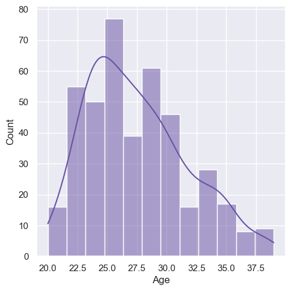

```r
# Python
sns.displot(x = 'Age', data = nba_stats, kde = True, color = my_color);
```

```r
# Python
age_big = nba_seasons['Age']
age_big = age_big.dropna()
print(len(age_big))
```

```
24616
```

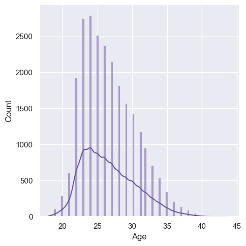

```r
# Python
sns.displot(x = 'Age', data = nba_seasons, kde = True, color = my_color);
```

```r
# R
age_small <- nba_stats$Age
age_small <- na.omit(age_small)

age_big <- nba_seasons$Age
age_big <- na.omit(age_big)
```

```r
length(age_small)
```

422

```r
length(age_big)
```

24616

**Графики квантилей:**

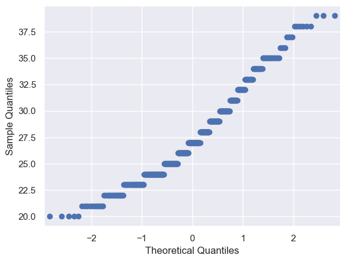

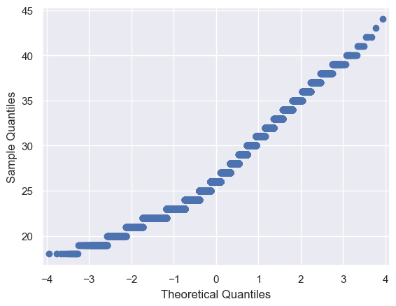

```r
# Python
sm.qqplot(age_small)
sm.qqplot(age_big)
plt.show()
```

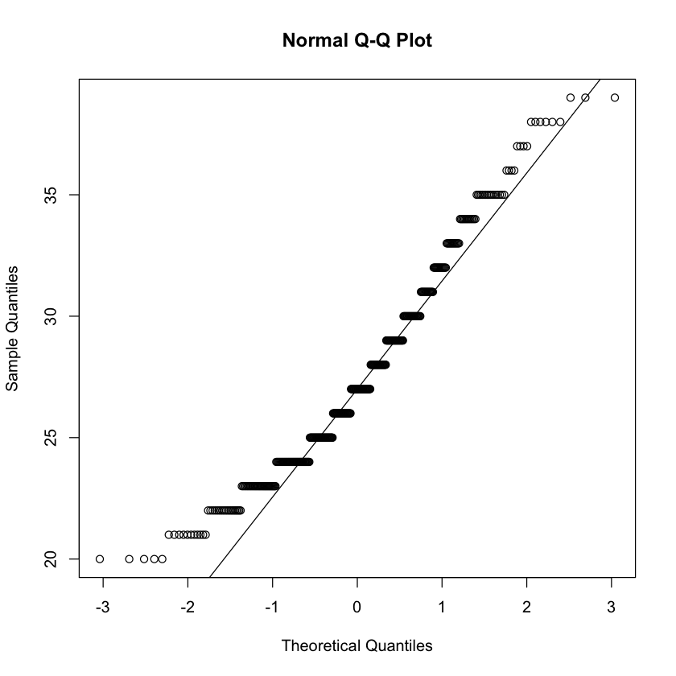

```r
# R
qqgraph <- function(x){
  qqnorm(x)
  qqline(x)
}

qqgraph(age_small)
```

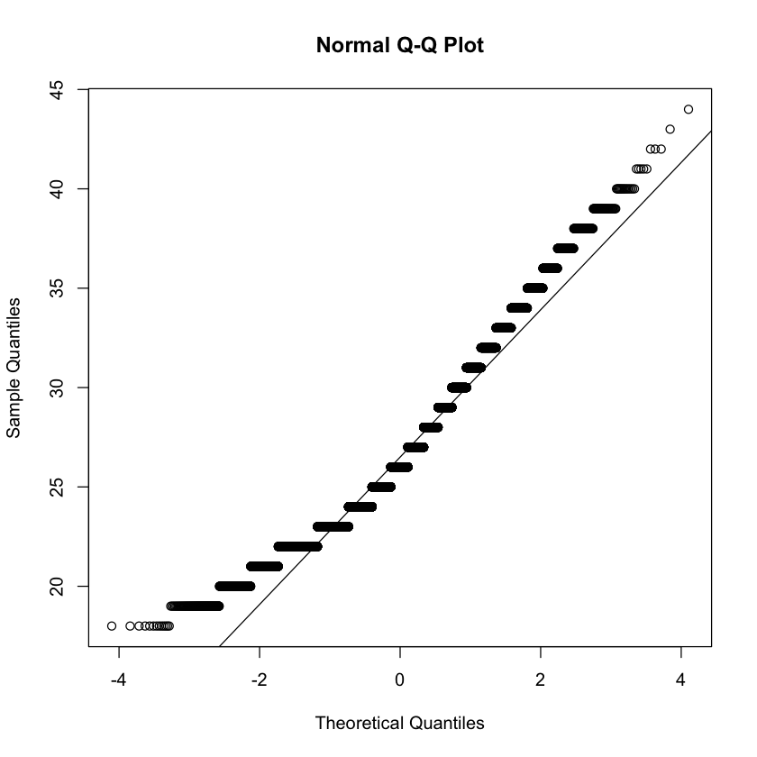

```r
qqgraph(age_big)
```

**Гипотезы о нормальности:**

**Малая выборка:**

```r
# Python
print(kstest(age_small, 'norm'))
print(shapiro(age_small))
print(anderson(age_small))
print(cramervonmises(age_small, 'norm'))
print(lilliefors(age_small, 'norm'))
```

```
KstestResult(statistic=1.0, pvalue=0.0)
ShapiroResult(statistic=0.9571580290794373, pvalue=9.831688796424487e-10)
AndersonResult(statistic=5.672400009454407, critical_values=array([0.571, 0.65 , 0.78 , 0.91 , 1.082]), significance_level=array([15. , 10. ,  5. ,  2.5,  1. ]))
CramerVonMisesResult(statistic=140.66666666666669, pvalue=0)
(0.11000548571765262, 0.0009999999999998899)
```

`p_value` < 0.05 по всем критериям. Значит данные не распределены нормально.  
В критерии Андерсона-Дарлинга полученное значение статистики больше критических значений -> нулевая гипотеза $H_0$ о нормальном распределении неверна.

Аналогичные результаты получаем с помощью тестов, реализованных с помощью функций на языке R:

```
	Asymptotic one-sample Kolmogorov-Smirnov test

data:  age_small
D = 1, p-value < 2.2e-16
alternative hypothesis: two-sided
```

```
	Shapiro-Wilk normality test

data:  age_small
W = 0.95716, p-value = 9.835e-10
```

```
	Anderson-Darling normality test

data:  age_small
A = 5.6724, p-value = 5.413e-14
```

```
	Cramer-von Mises normality test

data:  age_small
W = 0.92769, p-value = 3.005e-09
```

```
	Lilliefors (Kolmogorov-Smirnov) normality test

data:  age_small
D = 0.11001, p-value = 2.533e-13
```

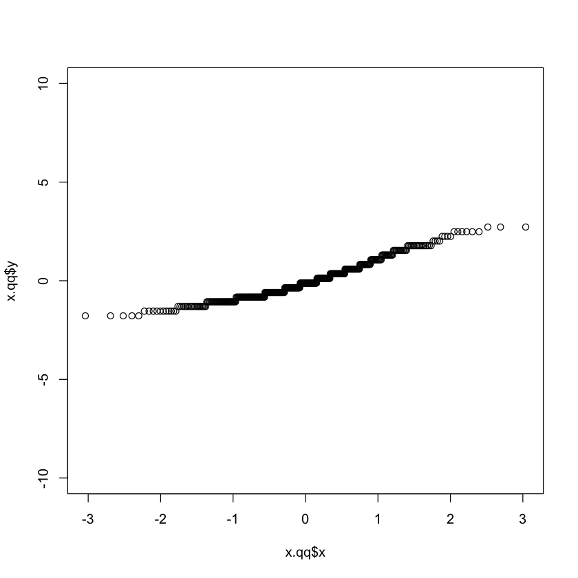

```r
# R
envelmet(age_small)
ks.test(age_small, "pnorm")
shapiro.test(age_small)
ad.test(age_small)
cvm.test(age_small)
lillie.test(age_small)
```

**Умеренная выборка:**

```r
# Python
print(kstest(age_big, 'norm'))
print(shapiro(age_big))
print(anderson(age_big))
print(cramervonmises(age_big, 'norm'))
print(lilliefors(age_big, 'norm'))
```

```
KstestResult(statistic=1.0, pvalue=0.0)
ShapiroResult(statistic=0.9604790806770325, pvalue=0.0)
AndersonResult(statistic=314.8563269767292, critical_values=array([0.576, 0.656, 0.787, 0.918, 1.092]), significance_level=array([15. , 10. ,  5. ,  2.5,  1. ]))
CramerVonMisesResult(statistic=8205.333333333334, pvalue=0)
(0.1147226994720083, 0.0009999999999998899)
```

```
	Asymptotic one-sample Kolmogorov-Smirnov test

data:  age_big
D = 1, p-value < 2.2e-16
alternative hypothesis: two-sided
```

```
	Anderson-Darling normality test

data:  age_big
A = 314.86, p-value < 2.2e-16
```

```
	Cramer-von Mises normality test

data:  age_big
W = 52.883, p-value = 7.37e-10
```

```
	Lilliefors (Kolmogorov-Smirnov) normality test

data:  age_big
D = 0.11472, p-value < 2.2e-16
```

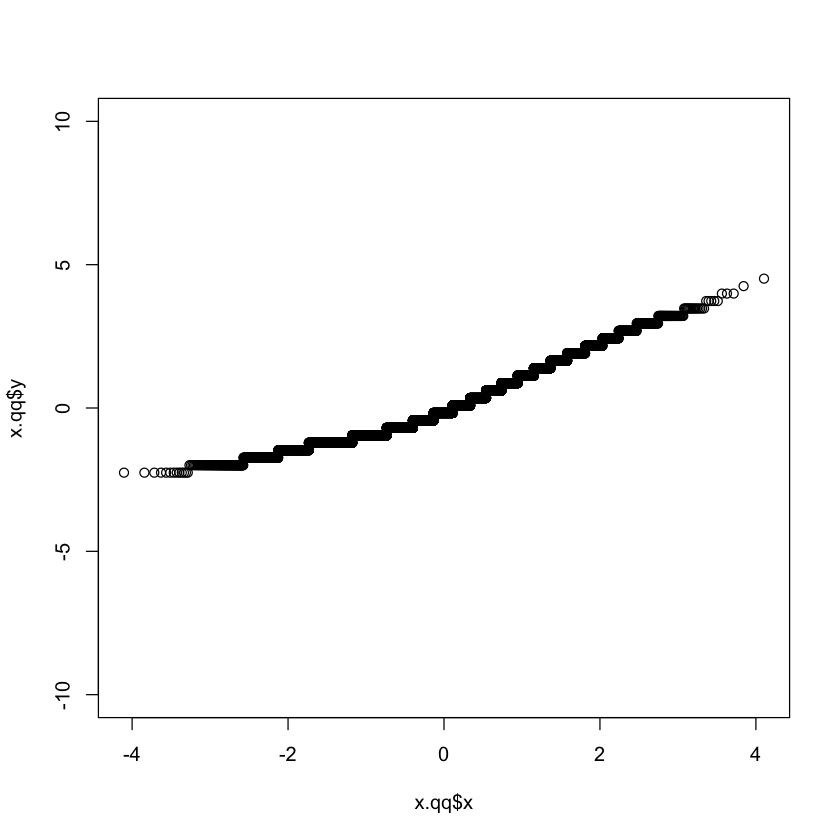

```r
# R
envelmet(age_big)
ks.test(age_big, "pnorm")
ad.test(age_big)
cvm.test(age_big)
lillie.test(age_big)
```

Аналогичная ситуация и с данными умеренной выборки.  
**Вывод**: возраст игроков в лиге не распределён нормально.

## Продемонстрировать применение для проверки различных гипотез и различных доверительных уровней (0.9, 0.95, 0.99) следующих критериев: Стьюдента, включая односторонние варианты, когда проверяемая нулевая гипотеза заключается в том, что одно из сравниваемых средних значений больше (или меньше) другого. Реализовать оценку мощности критериев при заданном объеме выборки или определения объема выборки для достижения заданной мощности; Уилкоксона-Манна-Уитни (ранговые); Фишера, Левене, Бартлетта, Флигнера-Килина (проверка гипотез об однородности дисперсий).

```r
# Python
norm0_4 = np.random.normal(0, 4, size = 100)
norm1_1 = np.random.normal(1, 1, size = 500)
norm0_9 = np.random.normal(0, 9, size = 3000)

from pingouin import ttest
```

```r
# R
norm0_4 <-  rnorm(100, sd = 4)
norm1_1 <- rnorm(500, mean = 1, sd = 11)
norm0_9 <- rnorm(3000, mean = 0, sd = 9)
```

**Критерий Стьюдента:**

**Доверительный уровень 0.9:**

```r
# Python
ttest(norm0_4, norm0_9, alternative = 'two-sided', confidence = 0.9)
```

|  | T | dof | alternative | p-val | CI90% | cohen-d | BF10 | power |
| --- | --- | --- | --- | --- | --- | --- | --- | --- |
| T-test | 0.439744 | 135.633255 | two-sided | 0.660822 | [-0.5297524396508206, 0.9127699971995367] | 0.021283 | 0.123 | 0.055033 |

```r
# Python
ttest(norm0_4, norm0_9, alternative = 'greater', confidence = 0.9)
```

|  | T | dof | alternative | p-val | CI90% | cohen-d | BF10 | power |
| --- | --- | --- | --- | --- | --- | --- | --- | --- |
| T-test | 0.439744 | 135.633255 | greater | 0.330411 | [-0.3693395772032982, inf] | 0.021283 | 0.247 | 0.075568 |

```r
# Python
ttest(norm0_4, norm1_1, alternative = 'two-sided', confidence = 0.9)
```

|  | T | dof | alternative | p-val | CI90% | cohen-d | BF10 | power |
| --- | --- | --- | --- | --- | --- | --- | --- | --- |
| T-test | -1.773973 | 101.090457 | two-sided | 0.079079 | [-1.3892411953747899, -0.0460806155829652] | 0.389683 | 0.545 | 0.944265 |

```r
# Python
ttest(norm0_4, norm1_1, alternative = 'greater', confidence = 0.9)
```

|  | T | dof | alternative | p-val | CI90% | cohen-d | BF10 | power |
| --- | --- | --- | --- | --- | --- | --- | --- | --- |
| T-test | -1.773973 | 101.090457 | greater | 0.960461 | [-1.2395233893655442, inf] | 0.389683 | 0.918 | 9.963661e-08 |

```r
# Python
ttest(norm1_1, norm0_9, alternative = 'two-sided', confidence = 0.9)
```

|  | T | dof | alternative | p-val | CI90% | cohen-d | BF10 | power |
| --- | --- | --- | --- | --- | --- | --- | --- | --- |
| T-test | 5.301883 | 3303.984313 | two-sided | 1.221444e-07 | [0.6270301938908214, 1.1913091746156503] | 0.107615 | 5.799e+04 | 0.605385 |

```r
# Python
ttest(norm1_1, norm0_9, alternative = 'greater', confidence = 0.9)
```

|  | T | dof | alternative | p-val | CI90% | cohen-d | BF10 | power |
| --- | --- | --- | --- | --- | --- | --- | --- | --- |
| T-test | 5.301883 | 3303.984313 | greater | 6.107219e-08 | [0.6893645863387176, inf] | 0.107615 | 1.16e+05 | 0.719907 |

```r
# R
t.test(norm0_4, mu = 0, conf.level = 0.9)
t.test(norm0_4, mu = 0.7, conf.level = 0.9)
t.test(norm0_4, mu = 0.5, conf.level = 0.9)

t.test(norm1_1, mu = 0, conf.level = 0.9)
t.test(norm1_1, mu = 15, conf.level = 0.9)
t.test(norm1_1, mu = 9.5, conf.level = 0.9)

t.test(norm0_9, mu = 0.316, conf.level = 0.9)
t.test(norm0_9, mu = 0.25, conf.level = 0.9)
t.test(norm0_9, mu = 0.41, conf.level = 0.9)
```

```
	One Sample t-test

data:  norm0_4
t = -0.45007, df = 99, p-value = 0.6536
alternative hypothesis: true mean is not equal to 0
90 percent confidence interval:
 -0.8675536  0.4975287
sample estimates:
 mean of x
-0.1850124
```

```
	One Sample t-test

data:  norm0_4
t = -2.1529, df = 99, p-value = 0.03375
alternative hypothesis: true mean is not equal to 0.7
90 percent confidence interval:
 -0.8675536  0.4975287
sample estimates:
 mean of x
-0.1850124
```

```
	One Sample t-test

data:  norm0_4
t = -1.6664, df = 99, p-value = 0.09879
alternative hypothesis: true mean is not equal to 0.5
90 percent confidence interval:
 -0.8675536  0.4975287
sample estimates:
 mean of x
-0.1850124
```

```
	One Sample t-test

data:  norm1_1
t = 1.6535, df = 499, p-value = 0.09886
alternative hypothesis: true mean is not equal to 0
90 percent confidence interval:
 0.002855503 1.688595721
sample estimates:
mean of x
0.8457256
```

```
	One Sample t-test

data:  norm1_1
t = -27.673, df = 499, p-value < 2.2e-16
alternative hypothesis: true mean is not equal to 15
90 percent confidence interval:
 0.002855503 1.688595721
sample estimates:
mean of x
0.8457256
```

```
	One Sample t-test

data:  norm1_1
t = -16.92, df = 499, p-value < 2.2e-16
alternative hypothesis: true mean is not equal to 9.5
90 percent confidence interval:
 0.002855503 1.688595721
sample estimates:
mean of x
0.8457256
```

```
	One Sample t-test

data:  norm0_9
t = -1.5239, df = 2999, p-value = 0.1276
alternative hypothesis: true mean is not equal to 0.316
90 percent confidence interval:
 -0.1956324  0.3356104
sample estimates:
mean of x
 0.069989
```

```
	One Sample t-test

data:  norm0_9
t = -1.1151, df = 2999, p-value = 0.2649
alternative hypothesis: true mean is not equal to 0.25
90 percent confidence interval:
 -0.1956324  0.3356104
sample estimates:
mean of x
 0.069989
```

```
	One Sample t-test

data:  norm0_9
t = -2.1062, df = 2999, p-value = 0.03527
alternative hypothesis: true mean is not equal to 0.41
90 percent confidence interval:
 -0.1956324  0.3356104
sample estimates:
mean of x
 0.069989
```

**Доверительный уровень 0.95:**

```r
# Python
ttest(norm0_4, norm0_9, alternative = 'two-sided', confidence = 0.95)
```

|  | T | dof | alternative | p-val | CI95% | cohen-d | BF10 | power |
| --- | --- | --- | --- | --- | --- | --- | --- | --- |
| T-test | 0.439744 | 135.633255 | two-sided | 0.660822 | [-0.67, 1.05] | 0.021283 | 0.123 | 0.055033 |

```r
# Python
ttest(norm0_4, norm0_9, alternative = 'greater', confidence = 0.95)
```

|  | T | dof | alternative | p-val | CI95% | cohen-d | BF10 | power |
| --- | --- | --- | --- | --- | --- | --- | --- | --- |
| T-test | 0.439744 | 135.633255 | greater | 0.330411 | [-0.53, inf] | 0.021283 | 0.247 | 0.075568 |

```r
# Python
ttest(norm0_4, norm1_1, alternative = 'two-sided', confidence = 0.95)
```

|  | T | dof | alternative | p-val | CI95% | cohen-d | BF10 | power |
| --- | --- | --- | --- | --- | --- | --- | --- | --- |
| T-test | -1.773973 | 101.090457 | two-sided | 0.079079 | [-1.52, 0.08] | 0.389683 | 0.545 | 0.944265 |

```r
# Python
ttest(norm0_4, norm1_1, alternative = 'greater', confidence = 0.95)
```

|  | T | dof | alternative | p-val | CI95% | cohen-d | BF10 | power |
| --- | --- | --- | --- | --- | --- | --- | --- | --- |
| T-test | -1.773973 | 101.090457 | greater | 0.960461 | [-1.39, inf] | 0.389683 | 0.918 | 9.963661e-08 |

```r
# Python
ttest(norm1_1, norm0_9, alternative = 'greater', confidence = 0.95)
```

|  | T | dof | alternative | p-val | CI95% | cohen-d | BF10 | power |
| --- | --- | --- | --- | --- | --- | --- | --- | --- |
| T-test | 5.301883 | 3303.984313 | greater | 6.107219e-08 | [0.63, inf] | 0.107615 | 1.16e+05 | 0.719907 |

```r
# Python
ttest(norm1_1, norm0_9, alternative = 'greater', confidence = 0.95)
```

|  | T | dof | alternative | p-val | CI95% | cohen-d | BF10 | power |
| --- | --- | --- | --- | --- | --- | --- | --- | --- |
| T-test | 5.301883 | 3303.984313 | greater | 6.107219e-08 | [0.63, inf] | 0.107615 | 1.16e+05 | 0.719907 |

```r
# R
t.test(norm0_4, mu = 0, conf.level = 0.95)
t.test(norm0_4, mu = 0.7, conf.level = 0.95)
t.test(norm0_4, mu = 0.5, conf.level = 0.95)

t.test(norm1_1, mu = 0, conf.level = 0.95)
t.test(norm1_1, mu = 15, conf.level = 0.95)
t.test(norm1_1, mu = 9.5, conf.level = 0.95)

t.test(norm0_9, mu = 0.316, conf.level = 0.95)
t.test(norm0_9, mu = 0.25, conf.level = 0.95)
t.test(norm0_9, mu = 0.41, conf.level = 0.95)
```

```
	One Sample t-test

data:  norm0_4
t = -0.45007, df = 99, p-value = 0.6536
alternative hypothesis: true mean is not equal to 0
95 percent confidence interval:
 -1.0006695  0.6306446
sample estimates:
 mean of x
-0.1850124
```

```
	One Sample t-test

data:  norm0_4
t = -2.1529, df = 99, p-value = 0.03375
alternative hypothesis: true mean is not equal to 0.7
95 percent confidence interval:
 -1.0006695  0.6306446
sample estimates:
 mean of x
-0.1850124
```

```
	One Sample t-test

data:  norm0_4
t = -1.6664, df = 99, p-value = 0.09879
alternative hypothesis: true mean is not equal to 0.5
95 percent confidence interval:
 -1.0006695  0.6306446
sample estimates:
 mean of x
-0.1850124
```

```
	One Sample t-test

data:  norm1_1
t = 1.6535, df = 499, p-value = 0.09886
alternative hypothesis: true mean is not equal to 0
95 percent confidence interval:
 -0.1591889  1.8506401
sample estimates:
mean of x
0.8457256
```

```
	One Sample t-test

data:  norm1_1
t = -27.673, df = 499, p-value < 2.2e-16
alternative hypothesis: true mean is not equal to 15
95 percent confidence interval:
 -0.1591889  1.8506401
sample estimates:
mean of x
0.8457256
```

```
	One Sample t-test

data:  norm1_1
t = -16.92, df = 499, p-value < 2.2e-16
alternative hypothesis: true mean is not equal to 9.5
95 percent confidence interval:
 -0.1591889  1.8506401
sample estimates:
mean of x
0.8457256
```

```
	One Sample t-test

data:  norm0_9
t = -1.5239, df = 2999, p-value = 0.1276
alternative hypothesis: true mean is not equal to 0.316
95 percent confidence interval:
 -0.2465484  0.3865264
sample estimates:
mean of x
 0.069989
```

```
	One Sample t-test

data:  norm0_9
t = -1.1151, df = 2999, p-value = 0.2649
alternative hypothesis: true mean is not equal to 0.25
95 percent confidence interval:
 -0.2465484  0.3865264
sample estimates:
mean of x
 0.069989
```

```
	One Sample t-test

data:  norm0_9
t = -2.1062, df = 2999, p-value = 0.03527
alternative hypothesis: true mean is not equal to 0.41
95 percent confidence interval:
 -0.2465484  0.3865264
sample estimates:
mean of x
 0.069989
```

**Доверительный уровень 0.99:**

```r
# Python
ttest(norm0_4, norm0_9, alternative = 'two-sided', confidence = 0.99)
```

|  | T | dof | alternative | p-val | CI99% | cohen-d | BF10 | power |
| --- | --- | --- | --- | --- | --- | --- | --- | --- |
| T-test | 0.439744 | 135.633255 | two-sided | 0.660822 | [-0.94626419665355, 1.3292817542022657] | 0.021283 | 0.123 | 0.055033 |

```r
# Python
ttest(norm0_4, norm0_9, alternative = 'greater', confidence = 0.99)
```

|  | T | dof | alternative | p-val | CI99% | cohen-d | BF10 | power |
| --- | --- | --- | --- | --- | --- | --- | --- | --- |
| T-test | 0.439744 | 135.633255 | greater | 0.330411 | [-0.8337273560405114, inf] | 0.021283 | 0.247 | 0.075568 |

```r
# Python
ttest(norm0_4, norm1_1, alternative = 'two-sided', confidence = 0.99)
```

|  | T | dof | alternative | p-val | CI99% | cohen-d | BF10 | power |
| --- | --- | --- | --- | --- | --- | --- | --- | --- |
| T-test | -1.773973 | 101.090457 | two-sided | 0.079079 | [-1.7797429060190684, 0.34442109506131324] | 0.389683 | 0.545 | 0.944265 |

```r
# Python
ttest(norm0_4, norm1_1, alternative = 'greater', confidence = 0.99)
```

|  | T | dof | alternative | p-val | CI99% | cohen-d | BF10 | power |
| --- | --- | --- | --- | --- | --- | --- | --- | --- |
| T-test | -1.773973 | 101.090457 | greater | 0.960461 | [-1.673937589494286, inf] | 0.389683 | 0.918 | 9.963661e-08 |

```r
# Python
ttest(norm1_1, norm0_9, alternative = 'greater', confidence = 0.99)
```

|  | T | dof | alternative | p-val | CI99% | cohen-d | BF10 | power |
| --- | --- | --- | --- | --- | --- | --- | --- | --- |
| T-test | 5.301883 | 3303.984313 | greater | 6.107219e-08 | [0.5100526692543756, inf] | 0.107615 | 1.16e+05 | 0.719907 |

```r
# Python
ttest(norm1_1, norm0_9, alternative = 'greater', confidence = 0.99)
```

|  | T | dof | alternative | p-val | CI99% | cohen-d | BF10 | power |
| --- | --- | --- | --- | --- | --- | --- | --- | --- |
| T-test | 5.301883 | 3303.984313 | greater | 6.107219e-08 | [0.5100526692543756, inf] | 0.107615 | 1.16e+05 | 0.719907 |

```r
# R
t.test(norm0_4, mu = 0, conf.level = 0.99)
t.test(norm0_4, mu = 0.7, conf.level = 0.99)
t.test(norm0_4, mu = 0.5, conf.level = 0.99)

t.test(norm1_1, mu = 0, conf.level = 0.99)
t.test(norm1_1, mu = 15, conf.level = 0.99)
t.test(norm1_1, mu = 9.5, conf.level = 0.99)

t.test(norm0_9, mu = 0.316, conf.level = 0.99)
t.test(norm0_9, mu = 0.25, conf.level = 0.99)
t.test(norm0_9, mu = 0.41, conf.level = 0.99)
```

```
	One Sample t-test

data:  norm0_4
t = -0.45007, df = 99, p-value = 0.6536
alternative hypothesis: true mean is not equal to 0
99 percent confidence interval:
 -1.2646555  0.8946306
sample estimates:
 mean of x
-0.1850124
```

```
	One Sample t-test

data:  norm0_4
t = -2.1529, df = 99, p-value = 0.03375
alternative hypothesis: true mean is not equal to 0.7
99 percent confidence interval:
 -1.2646555  0.8946306
sample estimates:
 mean of x
-0.1850124
```

```
	One Sample t-test

data:  norm0_4
t = -1.6664, df = 99, p-value = 0.09879
alternative hypothesis: true mean is not equal to 0.5
99 percent confidence interval:
 -1.2646555  0.8946306
sample estimates:
 mean of x
-0.1850124
```

```
	One Sample t-test

data:  norm1_1
t = 1.6535, df = 499, p-value = 0.09886
alternative hypothesis: true mean is not equal to 0
99 percent confidence interval:
 -0.4768103  2.1682616
sample estimates:
mean of x
0.8457256
```

```
	One Sample t-test

data:  norm1_1
t = -27.673, df = 499, p-value < 2.2e-16
alternative hypothesis: true mean is not equal to 15
99 percent confidence interval:
 -0.4768103  2.1682616
sample estimates:
mean of x
0.8457256
```

```
	One Sample t-test

data:  norm1_1
t = -16.92, df = 499, p-value < 2.2e-16
alternative hypothesis: true mean is not equal to 9.5
99 percent confidence interval:
 -0.4768103  2.1682616
sample estimates:
mean of x
0.8457256
```

```
	One Sample t-test

data:  norm0_9
t = -1.5239, df = 2999, p-value = 0.1276
alternative hypothesis: true mean is not equal to 0.316
99 percent confidence interval:
 -0.3461086  0.4860866
sample estimates:
mean of x
 0.069989
```

```
	One Sample t-test

data:  norm0_9
t = -1.1151, df = 2999, p-value = 0.2649
alternative hypothesis: true mean is not equal to 0.25
99 percent confidence interval:
 -0.3461086  0.4860866
sample estimates:
mean of x
 0.069989
```

```
	One Sample t-test

data:  norm0_9
t = -2.1062, df = 2999, p-value = 0.03527
alternative hypothesis: true mean is not equal to 0.41
99 percent confidence interval:
 -0.3461086  0.4860866
sample estimates:
mean of x
 0.069989
```

```r
# R
t.test(norm0_4, norm0_9, alternative = 'two.sided')
t.test(norm0_4, norm0_9, alternative = 'greater')
t.test(norm0_4, norm0_9, alternative = 'less')

t.test(norm0_4, norm1_1, alternative = 'two.sided')
t.test(norm0_4, norm1_1, alternative = 'greater')
t.test(norm0_4, norm1_1, alternative = 'less')
```

```
	Welch Two Sample t-test

data:  norm0_4 and norm0_9
t = -0.5774, df = 131.79, p-value = 0.5647
alternative hypothesis: true difference in means is not equal to 0
95 percent confidence interval:
 -1.1286140  0.6186111
sample estimates:
 mean of x  mean of y
-0.1850124  0.0699890
```

```
	Welch Two Sample t-test

data:  norm0_4 and norm0_9
t = -0.5774, df = 131.79, p-value = 0.7177
alternative hypothesis: true difference in means is greater than 0
95 percent confidence interval:
 -0.9865705        Inf
sample estimates:
 mean of x  mean of y
-0.1850124  0.0699890
```

```
	Welch Two Sample t-test

data:  norm0_4 and norm0_9
t = -0.5774, df = 131.79, p-value = 0.2823
alternative hypothesis: true difference in means is less than 0
95 percent confidence interval:
      -Inf 0.4765676
sample estimates:
 mean of x  mean of y
-0.1850124  0.0699890
```

```
	Welch Two Sample t-test

data:  norm0_4 and norm1_1
t = -1.5708, df = 435.66, p-value = 0.117
alternative hypothesis: true difference in means is not equal to 0
95 percent confidence interval:
 -2.3204362  0.2589601
sample estimates:
 mean of x  mean of y
-0.1850124  0.8457256
```

```
	Welch Two Sample t-test

data:  norm0_4 and norm1_1
t = -1.5708, df = 435.66, p-value = 0.9415
alternative hypothesis: true difference in means is greater than 0
95 percent confidence interval:
 -2.11238      Inf
sample estimates:
 mean of x  mean of y
-0.1850124  0.8457256
```

```
	Welch Two Sample t-test

data:  norm0_4 and norm1_1
t = -1.5708, df = 435.66, p-value = 0.05848
alternative hypothesis: true difference in means is less than 0
95 percent confidence interval:
      -Inf 0.0509039
sample estimates:
 mean of x  mean of y
-0.1850124  0.8457256
```

**Критерий Уилкоксона-Манна-Уитни:**

Из документации к функции `mannwhineyu()`:

```
    We use the Mann-Whitney U test to assess whether there is a statistically
    significant difference in the diagnosis age of males and females.
    The null hypothesis is that the distribution of male diagnosis ages is
    the same as the distribution of female diagnosis ages. We decide
    that a confidence level of 95% is required to reject the null hypothesis
    in favor of the alternative that the distributions are different.
    Since the number of samples is very small and there are no ties in the
    data, we can compare the observed test statistic against the *exact*
    distribution of the test statistic under the null hypothesis.
```

Доверительный интервал = 0.95

```r
# Python
pois1 = np.random.poisson(7, 14)
pois3 = np.random.poisson(7, 7)
pois2 = np.random.poisson(14, 7)

from scipy.stats import mannwhitneyu

print(mannwhitneyu(pois1, pois2, alternative='two-sided'))
print(mannwhitneyu(pois1, pois3, alternative='two-sided'))
print(mannwhitneyu(pois3, pois2, alternative='two-sided'))
print(mannwhitneyu(pois1, pois2, alternative='greater'))
print(mannwhitneyu(pois1, pois3, alternative='greater'))
print(mannwhitneyu(pois3, pois2, alternative='greater'))
```

```
MannwhitneyuResult(statistic=7.0, pvalue=0.0018435085648001617)
MannwhitneyuResult(statistic=34.5, pvalue=0.29184054514378865)
MannwhitneyuResult(statistic=12.0, pvalue=0.1227059803065297)
MannwhitneyuResult(statistic=7.0, pvalue=0.9992871435804214)
MannwhitneyuResult(statistic=34.5, pvalue=0.8706322455321593)
MannwhitneyuResult(statistic=12.0, pvalue=0.9527517157249085)
```

```r
# R
pois1 <-  rpois(7, 14)
pois2 <- rpois(7, 7)
pois3 <- rpois(14, 7)

mean(pois1)
mean(pois2)
mean(pois3)

wilcox.test(pois1, mu = mean(pois1), exact = FALSE)
wilcox.test(pois2, mu = mean(pois2), exact = FALSE)
wilcox.test(pois3, mu = mean(pois3), exact = FALSE)
```

14.7142857142857

9.42857142857143

6.85714285714286

```
	Wilcoxon signed rank test with continuity correction

data:  pois1
V = 14, p-value = 1
alternative hypothesis: true location is not equal to 14.71429
```

```
	Wilcoxon signed rank test with continuity correction

data:  pois2
V = 13, p-value = 0.9325
alternative hypothesis: true location is not equal to 9.428571
```

```
	Wilcoxon signed rank test with continuity correction

data:  pois3
V = 56, p-value = 0.8502
alternative hypothesis: true location is not equal to 6.857143
```

**Критерии Фишера, Левене, Бартлетта, Флигнера-Килина (проверка гипотез об однородности дисперсий):**

Нулевая гипотеза $H_0$: дисперсии двух выборок равны.  
Гипотеза верна, если `p_value` > 0.05, и неверна, если `p_value` < 0.05.

```r
# Python
from scipy.stats import levene
from scipy.stats import bartlett
from scipy.stats import fligner
```

```r
# R
install.packages("ISwR")
library(ISwR)
```

**Критерий Фишера:**

```r
var.test(norm0_9, norm1_1)
var.test(norm0_9, norm0_4)
var.test(norm1_1, norm0_4)
```

```
	F test to compare two variances

data:  norm0_9 and norm1_1
F = 0.59773, num df = 2999, denom df = 499, p-value = 1.177e-15
alternative hypothesis: true ratio of variances is not equal to 1
95 percent confidence interval:
 0.5209966 0.6813025
sample estimates:
ratio of variances
         0.5977254
```

```
	F test to compare two variances

data:  norm0_9 and norm0_4
F = 4.6269, num df = 2999, denom df = 99, p-value < 2.2e-16
alternative hypothesis: true ratio of variances is not equal to 1
95 percent confidence interval:
 3.415246 6.033254
sample estimates:
ratio of variances
          4.626874
```

```
	F test to compare two variances

data:  norm1_1 and norm0_4
F = 7.7408, num df = 499, denom df = 99, p-value < 2.2e-16
alternative hypothesis: true ratio of variances is not equal to 1
95 percent confidence interval:
  5.608522 10.350208
sample estimates:
ratio of variances
          7.740802
```

```r
# R
# Возьмём все выборки размера 1000
norm0_4 <-  rnorm(1000, sd = 4)
norm1_1 <- rnorm(1000, mean = 1, sd = 11)
norm0_9 <- rnorm(1000, mean = 0, sd = 9)

f1 <- rep(1, 1000)
f2 <- rep(2, 1000)
f3 <- rep(3, 1000)
fact <- as.factor(c(f1, f2, f3))

ff1 <- rep(1, 1000)
ff2 <- rep(2, 1000)
ffact <- as.factor(c(ff1, ff2))

fff1 <- rep(1, 1000)
fff2 <- rep(3, 1000)
fffact <- as.factor(c(fff1, fff2))

vec_norm <- c(norm0_9, norm0_4, norm1_1)
vec_norm_2 <- c(norm0_9, norm0_4)
vec_norm_3 <- c(norm0_9, norm1_1)
```

**Критерий Левене:**

```r
# Python
print(levene(norm0_9, norm0_4))
print(levene(norm1_1, norm0_4))
print(levene(norm0_9, norm1_1))
```

```
LeveneResult(statistic=55.632554039145845, pvalue=1.1281252811432805e-13)
LeveneResult(statistic=448.7797567473351, pvalue=9.84633081494447e-75)
LeveneResult(statistic=730.2313157110283, pvalue=3.1619978885001836e-146)
```

```r
# R

leveneTest(vec_norm, fact)
leveneTest(vec_norm_2, ffact)
leveneTest(vec_norm_3, fffact)
```

A anova: 2 × 3

|  | Df <int> | F value <dbl> | Pr(>F) <dbl> |
| --- | --- | --- | --- |
| group | 2 | 314.5796 | 9.63711e-125 |
|  | 2997 | NA | NA |

A anova: 2 × 3

|  | Df <int> | F value <dbl> | Pr(>F) <dbl> |
| --- | --- | --- | --- |
| group | 1 | 488.1875 | 5.76389e-97 |
|  | 1998 | NA | NA |

A anova: 2 × 3

|  | Df <int> | F value <dbl> | Pr(>F) <dbl> |
| --- | --- | --- | --- |
| group | 1 | 28.05645 | 1.308014e-07 |
|  | 1998 | NA | NA |

**Критерий Бартлетта:**

```r
# Python
print(bartlett(norm0_9, norm0_4))
print(bartlett(norm1_1, norm0_4))
print(bartlett(norm0_9, norm1_1))
```

```
BartlettResult(statistic=80.88068224257, pvalue=2.3976608237950283e-19)
BartlettResult(statistic=533.0879750344642, pvalue=6.013769302812126e-118)
BartlettResult(statistic=1752.303450925947, pvalue=0.0)
```

```r
# R
bartlett.test(vec_norm, fact)
bartlett.test(vec_norm_2, ffact)
bartlett.test(vec_norm_3, fffact)
```

```
	Bartlett test of homogeneity of variances

data:  vec_norm and fact
Bartlett's K-squared = 940.76, df = 2, p-value < 2.2e-16
```

```
	Bartlett test of homogeneity of variances

data:  vec_norm_2 and ffact
Bartlett's K-squared = 644.14, df = 1, p-value < 2.2e-16
```

```
	Bartlett test of homogeneity of variances

data:  vec_norm_3 and fffact
Bartlett's K-squared = 37.196, df = 1, p-value = 1.068e-09
```

**Критерий Флингера-Килина:**

```r
# Python
print(fligner(norm0_9, norm0_4))
print(fligner(norm1_1, norm0_4))
print(fligner(norm0_9, norm1_1))
```

```
FlignerResult(statistic=55.723266091715566, pvalue=8.34250833710515e-14)
FlignerResult(statistic=205.87362629802112, pvalue=1.0918557674656273e-46)
FlignerResult(statistic=663.0473296466182, pvalue=3.2480073023743642e-146)
```

```r
# R
fligner.test(vec_norm, fact)
fligner.test(vec_norm_2, ffact)
fligner.test(vec_norm_3, fffact)
```

```
	Fligner-Killeen test of homogeneity of variances

data:  vec_norm and fact
Fligner-Killeen:med chi-squared = 541.17, df = 2, p-value < 2.2e-16
```

```
	Fligner-Killeen test of homogeneity of variances

data:  vec_norm_2 and ffact
Fligner-Killeen:med chi-squared = 390.47, df = 1, p-value < 2.2e-16
```

```
	Fligner-Killeen test of homogeneity of variances

data:  vec_norm_3 and fffact
Fligner-Killeen:med chi-squared = 26.915, df = 1, p-value = 2.126e-07
```

## Исследовать корреляционные взаимосвязи вданных с помощью коэффициентов корреляции Пирсона, Спирмена и Кендалла.

```r
# R
Height <- nba_stats$Height
BLK <- nba_stats$BLK
AST <- nba_stats$AST
STL <- nba_stats$STL
```

**Коэффициент корреляции Пирсона:**

```r
# Python
from scipy.stats import pearsonr

names = ['Age',  'PTS',  'Height', 'Weight', 'FGM','AST', 'STL', 'BLK']
data = nba_stats[names]
data = data.dropna()

print('Height / BLK:', pearsonr(data['Height'], data['BLK']))
print('Height / AST:',pearsonr(data['Height'], data['AST']))
print('Height / STL:',pearsonr(data['Height'], data['STL']))
```

```
Height / BLK: PearsonRResult(statistic=0.4598498367787574, pvalue=1.8048892179395132e-23)
Height / AST: PearsonRResult(statistic=-0.36580665368133997, pvalue=8.292216287886863e-15)
Height / STL: PearsonRResult(statistic=-0.16426314972308145, pvalue=0.0007055152427373476)
```

```r
# R
cor.test(Height, BLK, method = 'pearson')
cor.test(Height, AST, method = 'pearson')
cor.test(Height, STL, method = 'pearson')
```

```
	Pearson's product-moment correlation

data:  Height and BLK
t = 10.613, df = 420, p-value < 2.2e-16
alternative hypothesis: true correlation is not equal to 0
95 percent confidence interval:
 0.3811209 0.5319576
sample estimates:
      cor
0.4598498
```

```
	Pearson's product-moment correlation

data:  Height and AST
t = -8.0551, df = 420, p-value = 8.292e-15
alternative hypothesis: true correlation is not equal to 0
95 percent confidence interval:
 -0.4457019 -0.2801297
sample estimates:
       cor
-0.3658067
```

```
	Pearson's product-moment correlation

data:  Height and STL
t = -3.4127, df = 420, p-value = 0.0007055
alternative hypothesis: true correlation is not equal to 0
95 percent confidence interval:
 -0.25571244 -0.06990026
sample estimates:
       cor
-0.1642631
```

Можем видеть, что мы получили одинаковые результаты, используя функции на разных языках программирования.

**Коэффициент корреляции Спирмена:**

```r
# Python
from scipy.stats import spearmanr

print('Height / BLK:' spearmanr(data['Height'], data['BLK']))
print('Height / AST:', spearmanr(data['Height'], data['AST']))
print('Height / STL:', spearmanr(data['Height'], data['STL']))
```

```
Height / BLK: SpearmanrResult(correlation=0.49086355566615714, pvalue=5.663041101407075e-27)
Height / AST: SpearmanrResult(correlation=-0.28101517435422446, pvalue=4.242236021144623e-09)
Height / STL: SpearmanrResult(correlation=-0.13080153488531007, pvalue=0.007132209027723288)
```

```r
# R
cor.test(Height, BLK, method = 'spearman')
cor.test(Height, AST, method = 'spearman')
cor.test(Height, STL, method = 'spearman')
```

```
	Spearman's rank correlation rho

data:  Height and BLK
S = 6377021, p-value < 2.2e-16
alternative hypothesis: true rho is not equal to 0
sample estimates:
      rho
0.4908636
```

```
	Spearman's rank correlation rho

data:  Height and AST
S = 16044934, p-value = 4.242e-09
alternative hypothesis: true rho is not equal to 0
sample estimates:
       rho
-0.2810152
```

```
	Spearman's rank correlation rho

data:  Height and STL
S = 14163483, p-value = 0.007132
alternative hypothesis: true rho is not equal to 0
sample estimates:
       rho
-0.1308015
```

Аналогично получаем такие же значения

**Коэффициент корреляции Кендалла:**

```r
# Python
from scipy.stats import kendalltau

print('Height / BLK:', kendalltau(data['Height'], data['BLK']))
print('Height / AST:', kendalltau(data['Height'], data['AST']))
print('Height / STL:', kendalltau(data['Height'], data['STL']))
```

```
Height / BLK: KendalltauResult(correlation=0.3590468934834969, pvalue=1.1909574779196414e-25)
Height / AST: KendalltauResult(correlation=-0.19970873222355925, pvalue=3.939647458259811e-09)
Height / STL: KendalltauResult(correlation=-0.0923392307660423, pvalue=0.0066656373362833)
```

```r
# R
cor.test(Height, BLK, method = 'kendall')
cor.test(Height, AST, method = 'kendall')
cor.test(Height, STL, method = 'kendall')
```

```
	Kendall's rank correlation tau

data:  Height and BLK
z = 10.47, p-value < 2.2e-16
alternative hypothesis: true tau is not equal to 0
sample estimates:
      tau
0.3590469
```

```
	Kendall's rank correlation tau

data:  Height and AST
z = -5.8867, p-value = 3.94e-09
alternative hypothesis: true tau is not equal to 0
sample estimates:
       tau
-0.1997087
```

```
	Kendall's rank correlation tau

data:  Height and STL
z = -2.7131, p-value = 0.006666
alternative hypothesis: true tau is not equal to 0
sample estimates:
        tau
-0.09233923
```

Снова получили одинаковые результаты и на R, и на Python.

## Продемонстрировать использование методов хи-квадрат, точного теста Фишера, теста МакНемара, теста Кохрана-Мантеля-Хензеля.

**$\chi$-квадрат:**

```r
# Python
from scipy.stats import chisquare

obs = nba_stats_c['Height']
exp = [nba_stats_c['Height'].mean()]*nba_stats_c.shape[0]
print(chisquare(f_obs=obs, f_exp=exp))

obs = nba_stats_c['Weight']
exp = [nba_stats_c['Weight'].mean()]*nba_stats_c.shape[0]
print(chisquare(f_obs=obs, f_exp=exp))

obs = nba_stats_c['Age']
exp = [nba_stats_c['Age'].mean()]*nba_stats_c.shape[0]
print(chisquare(f_obs=obs, f_exp=exp))
```

```
Power_divergenceResult(statistic=4.823249206083904, pvalue=1.0)
Power_divergenceResult(statistic=45.216488082221744, pvalue=0.9927109810649787)
Power_divergenceResult(statistic=43.72166998011929, pvalue=0.995538512511413)
```

```r
# R
nba_stats_c <- nba_stats[nba_stats$Pos == "C", ]
chisq.test(nba_stats_c$Height)
chisq.test(nba_stats_c$Weight)
chisq.test(nba_stats_c$Age)
```

[output not shown]

```
	Chi-squared test for given probabilities

data:  nba_stats_c$Weight
X-squared = 45.216, df = 71, p-value = 0.9927
```

```
	Chi-squared test for given probabilities

data:  nba_stats_c$Age
X-squared = 43.722, df = 71, p-value = 0.9955
```

`pvalue` > 0.05. Делаем вывод о том, что среди игроков на центровой позиции рост, вес и возраст в среднем примерно одинаков.

**Точный тест Фишера:**

```r
# Python
center_pts = nba_stats[nba_stats['Pos'] == 'C'].PTS.mean()
pg_pts = nba_stats[nba_stats['Pos'] == 'PG'].PTS.mean()
sf_pts = nba_stats[nba_stats['Pos'] == 'SF'].PTS.mean()

center_ast = nba_stats[nba_stats['Pos'] == 'C'].AST.mean()
pg_ast = nba_stats[nba_stats['Pos'] == 'PG'].AST.mean()
sf_ast = nba_stats[nba_stats['Pos'] == 'SF'].AST.mean()

center_stl = nba_stats[nba_stats['Pos'] == 'C'].STL.mean()
pg_stl = nba_stats[nba_stats['Pos'] == 'PG'].STL.mean()
sf_stl = nba_stats[nba_stats['Pos'] == 'SF'].STL.mean()

k = [[center_pts, pg_pts], [center_ast, pg_ast]]
print(k)

k1 = [[center_pts, sf_pts], [center_ast, sf_ast]]
print(k1)

k2 = [[pg_pts, sf_pts], [pg_ast, sf_ast]]
print(k2)

k3 = [[pg_pts, sf_pts], [pg_stl, sf_stl]]
print(k3)

k4 = [[pg_pts, center_pts], [pg_stl, center_stl]]
print(k4)

k5 = [[center_pts, sf_pts], [center_stl, sf_stl]]
print(k5)
```

```
[[504.18055555555554, 556.75], [71.59722222222223, 225.96428571428572]]
[[504.18055555555554, 496.6578947368421], [71.59722222222223, 87.05263157894737]]
[[556.75, 496.6578947368421], [225.96428571428572, 87.05263157894737]]
[[556.75, 496.6578947368421], [49.642857142857146, 41.473684210526315]]
[[556.75, 504.18055555555554], [49.642857142857146, 31.15277777777778]]
[[504.18055555555554, 496.6578947368421], [31.15277777777778, 41.473684210526315]]
```

```r
# Python
from scipy.stats import fisher_exact

print(fisher_exact(k))
print(fisher_exact(k1))
print(fisher_exact(k2))
print(fisher_exact(k3))
print(fisher_exact(k4))
print(fisher_exact(k5))
```

```
(2.872631472286959, 1.494030281289387e-13)
(1.245115856428896, 0.23063081310415287)
(0.43344086021505374, 1.0897700865136263e-09)
(0.9379526003949967, 0.8261395894627419)
(0.6979267897635244, 0.13278977384648125)
(1.3439125910509886, 0.2720998899943202)
```

```r
# R
center_pts <- nba_stats[nba_stats$Pos == 'C', ]$PTS
pg_pts <- nba_stats[nba_stats$Pos == 'PG', ]$PTS
sf_pts <- nba_stats[nba_stats$Pos == 'SF', ]$PTS

center_ast <- nba_stats[nba_stats$Pos == 'C', ]$AST
pg_ast <- nba_stats[nba_stats$Pos == 'PG', ]$AST
sf_ast <- nba_stats[nba_stats$Pos == 'SF', ]$AST

center_stl <- nba_stats[nba_stats$Pos == 'C', ]$STL
pg_stl <- nba_stats[nba_stats$Pos == 'PG', ]$STL
sf_stl <- nba_stats[nba_stats$Pos == 'SF', ]$STL

k <- matrix(c(mean(center_pts), mean(pg_pts), mean(center_ast), mean(pg_ast)), nrow = 2, ncol = 2, byrow = TRUE, dimnames = list(c("C", "PG"), c("PTS", "AST")))

k1 <- matrix(c(mean(center_pts), mean(sf_pts), mean(center_ast), mean(sf_ast)), nrow = 2, ncol = 2, byrow = TRUE, dimnames = list(c("C", "SF"), c("PTS", "AST")))

k2 <- matrix(c(mean(pg_pts), mean(sf_pts), mean(pg_ast), mean(sf_ast)), nrow = 2, ncol = 2, byrow = TRUE, dimnames = list(c("PG", "SF"), c("PTS", "AST")))

k3 <- matrix(c(mean(pg_pts), mean(sf_pts), mean(pg_stl), mean(sf_stl)), nrow = 2, ncol = 2, byrow = TRUE, dimnames = list(c("PG", "SF"), c("PTS", "STL")))

k4 <- matrix(c(mean(pg_pts), mean(center_pts), mean(pg_stl), mean(center_stl)), nrow = 2, ncol = 2, byrow = TRUE, dimnames = list(c("PG", "C"), c("PTS", "STL")))

k5 <- matrix(c(mean(pg_pts), mean(center_pts), mean(pg_stl), mean(center_stl)), nrow = 2, ncol = 2, byrow = TRUE, dimnames = list(c("C", "SF"), c("PTS", "STL")))
```

```r
# R
fisher.test(k)
fisher.test(k1)
fisher.test(k2)
fisher.test(k3)
fisher.test(k4)
fisher.test(k5)
```

```
	Fisher's Exact Test for Count Data

data:  k
p-value = 1.876e-13
alternative hypothesis: true odds ratio is not equal to 1
95 percent confidence interval:
 2.106675 3.856384
sample estimates:
odds ratio
  2.838143
```

```
	Fisher's Exact Test for Count Data

data:  k1
p-value = 0.267
alternative hypothesis: true odds ratio is not equal to 1
95 percent confidence interval:
 0.8638926 1.7415110
sample estimates:
odds ratio
  1.225134
```

```
	Fisher's Exact Test for Count Data

data:  k2
p-value = 7.752e-10
alternative hypothesis: true odds ratio is not equal to 1
95 percent confidence interval:
 0.3236164 0.5722628
sample estimates:
odds ratio
 0.4316842
```

```
	Fisher's Exact Test for Count Data

data:  k3
p-value = 0.7432
alternative hypothesis: true odds ratio is not equal to 1
95 percent confidence interval:
 0.5820142 1.4444945
sample estimates:
odds ratio
 0.9190863
```

```
	Fisher's Exact Test for Count Data

data:  k4
p-value = 0.1328
alternative hypothesis: true odds ratio is not equal to 1
95 percent confidence interval:
 0.4161494 1.1138130
sample estimates:
odds ratio
 0.6854244
```

```
	Fisher's Exact Test for Count Data

data:  k5
p-value = 0.1328
alternative hypothesis: true odds ratio is not equal to 1
95 percent confidence interval:
 0.4161494 1.1138130
sample estimates:
odds ratio
 0.6854244
```

**Тест МакНемара:**

```r
# Python
from statsmodels.stats.contingency_tables import mcnemar

print(mcnemar(k, exact=False))
print(mcnemar(k1, exact=False))
print(mcnemar(k2, exact=False))
print(mcnemar(k3, exact=False))
print(mcnemar(k4, exact=False))
print(mcnemar(k5, exact=False))
```

```
pvalue      4.059522261449595e-83
statistic   373.04837825325603
pvalue      8.570073701204063e-71
statistic   316.4554943840585
pvalue      1.0955326535263276e-23
statistic   100.65376446402983
pvalue      3.534605970784704e-81
statistic   364.13900781848093
pvalue      9.222422172267522e-83
statistic   371.4116073194991
pvalue      6.714070718248257e-91
statistic   408.79242295953674
```

```r
# R
mcnemar.test(k)
mcnemar.test(k1)
mcnemar.test(k2)
mcnemar.test(k3)
mcnemar.test(k4)
mcnemar.test(k5)
```

```
	McNemar's Chi-squared test with continuity correction

data:  k
McNemar's chi-squared = 373.05, df = 1, p-value < 2.2e-16
```

```
	McNemar's Chi-squared test with continuity correction

data:  k1
McNemar's chi-squared = 316.46, df = 1, p-value < 2.2e-16
```

```
	McNemar's Chi-squared test with continuity correction

data:  k2
McNemar's chi-squared = 100.65, df = 1, p-value < 2.2e-16
```

```
	McNemar's Chi-squared test with continuity correction

data:  k3
McNemar's chi-squared = 364.14, df = 1, p-value < 2.2e-16
```

```
	McNemar's Chi-squared test with continuity correction

data:  k4
McNemar's chi-squared = 371.41, df = 1, p-value < 2.2e-16
```

```
	McNemar's Chi-squared test with continuity correction

data:  k5
McNemar's chi-squared = 371.41, df = 1, p-value < 2.2e-16
```

## Проверить наличие мультиколлинеарности в данных с помощью корреляционной матрицы фактора инфляции дисперсии.

**Корреляционная матрица:**

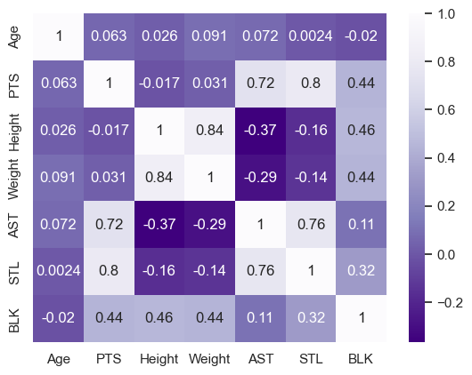

```r
# Python
names = ['Age',  'PTS',  'Height', 'Weight', 'AST', 'STL', 'BLK']

data = nba_stats[names]
data = data.dropna() # удаление строк с пропусками

fig = plt.figure()
sns.heatmap(data.corr(), cmap="Purples_r", annot=True)

plt.show()
```

Проделаем то же самое на R:

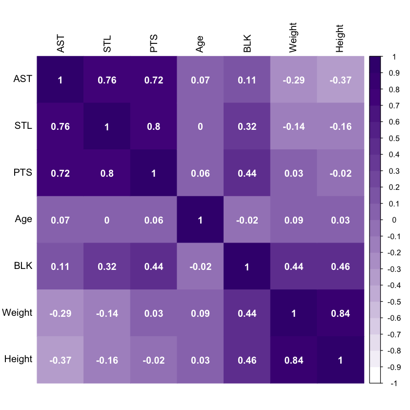

```r
# R
data3 <- nba_stats[, c(19, 25, 4, 33, 30, 17, 18)]

MATRIX <- cor(data3)
col4 <- colorRampPalette(c("white", "#3F007D"))

corrplot(MATRIX, method = "color", col = col4(20), cl.length = 21,
         order = "AOE",  tl.col = "black", addCoef.col = "white")
```

Итак, мы можем видеть, что существуют некоторые зависимости.

**Фактор инфляции дипсперсии:**

**Фактор инфляции дисперсии** — это мера мультиколлинеарности, которая существует в наборе переменных, участвующих в множественных регрессиях.

Как правило, значение vif выше 10 указывает на высокую корреляцию с другими независимыми переменными.

```r
# Python
from statsmodels.stats.outliers_influence import variance_inflation_factor
from statsmodels.tools.tools import add_constant

names = [ 'pts',  'player_height', 'player_weight', 'ast', 'reb', 'gp']

data = nba_players[names]
data = data.dropna() # удаление строк с пропусками

X = add_constant(data)
ds = pd.Series([variance_inflation_factor(X.values, i)
               for i in range(X.shape[1])],
              index=X.columns)
print(ds)
```

```
const            1156.930429
pts                 3.147758
player_height       3.692932
player_weight       3.308923
ast                 2.574216
reb                 2.773611
gp                  1.495791
dtype: float64
```

Данный метод не указывает на наличие корреляции моих данных, а именно взаимосвязи характеристик игрока и его игровых показателях.

## Исследовать зависимости в данных с помощью дисперсионного анализа.

```r
# Python
import scipy.stats as stats
from scipy.stats import f_oneway

c_pts = nba_stats[nba_stats['Pos'] == 'C']['PTS']
pg_pts = nba_stats[nba_stats['Pos'] == 'PG']['PTS']

c_ast = nba_stats[nba_stats['Pos'] == 'C']['AST']
pg_ast = nba_stats[nba_stats['Pos'] == 'PG']['AST']

c_stl = nba_stats[nba_stats['Pos'] == 'C']['STL']
pg_stl = nba_stats[nba_stats['Pos'] == 'PG']['STL']

print(stats.f_oneway(c_pts, pg_pts))
print(stats.f_oneway(c_ast, pg_ast))
print(stats.f_oneway(c_stl, pg_stl))
```

```
F_onewayResult(statistic=0.5985695617039988, pvalue=0.44031034129506275)
F_onewayResult(statistic=47.12073364294072, pvalue=1.537605699741845e-10)
F_onewayResult(statistic=11.496955949580935, pvalue=0.0008857699760405417)
```

Значение `pvalue` в сравнении количестве результативных передач (AST) и перехватов (STL) < 0.05. Можем сделать вывод о том, что эти показатели для игроков центровой и разыгрывающий не эквивалентны.  
Что касается количества очков (PTS), то разницы нет. Значит игроки и на той, и на другой позиции с одинаковым успехом набирают очки в игре.

**Однофакторный дисперсионный анализ:**

```r
# R
summary(aov(nba_stats$PTS ~ nba_stats$Pos))
```

```
               Df   Sum Sq Mean Sq F value Pr(>F)
nba_stats$Pos   4   320276   80069   0.438  0.781
Residuals     417 76174525  182673
```

**Линейная модель (Однофакторный дисперсионный анализ):**

```r
A1 <- lm(nba_stats$PTS ~ nba_stats$Pos)
summary(A1)
```

```
Call:
lm(formula = nba_stats$PTS ~ nba_stats$Pos)

Residuals:
   Min     1Q Median     3Q    Max
-556.8 -367.6  -83.0  275.1 1681.7

Coefficients:
                Estimate Std. Error t value Pr(>|t|)
(Intercept)      504.181     50.370  10.010   <2e-16 ***
nba_stats$PosPF  -22.358     67.578  -0.331    0.741
nba_stats$PosPG   52.569     68.643   0.766    0.444
nba_stats$PosSF   -7.523     70.290  -0.107    0.915
nba_stats$PosSG   31.099     66.059   0.471    0.638
---
Signif. codes:  0 ‘***’ 0.001 ‘**’ 0.01 ‘*’ 0.05 ‘.’ 0.1 ‘ ’ 1

Residual standard error: 427.4 on 417 degrees of freedom
Multiple R-squared:  0.004187,	Adjusted R-squared:  -0.005365
F-statistic: 0.4383 on 4 and 417 DF,  p-value: 0.7809
```

**Таблица дисперсионного анализа:**

```r
anova(A)
```

A anova: 2 × 5

|  | Df <int> | Sum Sq <dbl> | Mean Sq <dbl> | F value <dbl> | Pr(>F) <dbl> |
| --- | --- | --- | --- | --- | --- |
| nba_stats$Pos | 4 | 320276.2 | 80069.04 | 0.4383196 | 0.7809246 |
| Residuals | 417 | 76174524.8 | 182672.72 | NA | NA |

**Двухфакторный дисперсионный анализ:**

```r
A2 <- lm(nba_stats$PTS ~ nba_stats$Pos*nba_stats$Age)
summary(A2)
anova(A2)
```

```
Call:
lm(formula = nba_stats$PTS ~ nba_stats$Pos * nba_stats$Age)

Residuals:
    Min      1Q  Median      3Q     Max
-619.36 -339.74  -79.32  254.80 1699.15

Coefficients:
                              Estimate Std. Error t value Pr(>|t|)
(Intercept)                     820.96     344.57   2.383   0.0176 *
nba_stats$PosPF                -773.02     448.18  -1.725   0.0853 .
nba_stats$PosPG                -242.60     471.09  -0.515   0.6068
nba_stats$PosSF                -445.62     471.71  -0.945   0.3454
nba_stats$PosSG                -812.15     443.93  -1.829   0.0681 .
nba_stats$Age                   -11.34      12.20  -0.929   0.3533
nba_stats$PosPF:nba_stats$Age    26.90      15.87   1.695   0.0908 .
nba_stats$PosPG:nba_stats$Age    10.54      16.89   0.624   0.5329
nba_stats$PosSF:nba_stats$Age    15.70      16.73   0.938   0.3487
nba_stats$PosSG:nba_stats$Age    30.91      15.96   1.937   0.0534 .
---
Signif. codes:  0 ‘***’ 0.001 ‘**’ 0.01 ‘*’ 0.05 ‘.’ 0.1 ‘ ’ 1

Residual standard error: 426.4 on 412 degrees of freedom
Multiple R-squared:  0.02079,	Adjusted R-squared:  -0.0006023
F-statistic: 0.9718 on 9 and 412 DF,  p-value: 0.4627
```

A anova: 4 × 5

|  | Df <int> | Sum Sq <dbl> | Mean Sq <dbl> | F value <dbl> | Pr(>F) <dbl> |
| --- | --- | --- | --- | --- | --- |
| nba_stats$Pos | 4 | 320276.2 | 80069.04 | 0.4404061 | 0.7794033 |
| nba_stats$Age | 1 | 367483.4 | 367483.42 | 2.0212799 | 0.1558649 |
| nba_stats$Pos:nba_stats$Age | 4 | 902436.7 | 225609.17 | 1.2409247 | 0.2928848 |
| Residuals | 412 | 74904604.7 | 181807.29 | NA | NA |

**Трёхфакторный дисперсионный анализ:**

```r
A2 <- lm(nba_stats$PTS ~ nba_stats$Pos*nba_stats$Age*nba_stats$Height)
summary(A2)
anova(A2)
```

```
Call:
lm(formula = nba_stats$PTS ~ nba_stats$Pos * nba_stats$Age *
    nba_stats$Height)

Residuals:
    Min      1Q  Median      3Q     Max
-627.70 -328.86  -76.88  256.05 1702.90

Coefficients:
                                                 Estimate Std. Error t value
(Intercept)                                     31078.865  17905.677   1.736
nba_stats$PosPF                                -21908.180  27411.683  -0.799
nba_stats$PosPG                                -36707.431  22561.917  -1.627
nba_stats$PosSF                                -12793.442  31403.253  -0.407
nba_stats$PosSG                                -35834.687  22440.746  -1.597
nba_stats$Age                                   -1168.918    638.410  -1.831
nba_stats$Height                                 -146.012     86.167  -1.695
nba_stats$PosPF:nba_stats$Age                     655.180    958.602   0.683
nba_stats$PosPG:nba_stats$Age                    1429.410    823.111   1.737
nba_stats$PosSF:nba_stats$Age                     458.231   1127.857   0.406
nba_stats$PosSG:nba_stats$Age                    1249.439    808.620   1.545
nba_stats$PosPF:nba_stats$Height                  101.437    133.307   0.761
nba_stats$PosPG:nba_stats$Height                  179.405    113.335   1.583
nba_stats$PosSF:nba_stats$Height                   56.035    155.431   0.361
nba_stats$PosSG:nba_stats$Height                  170.499    110.991   1.536
nba_stats$Age:nba_stats$Height                      5.588      3.076   1.817
nba_stats$PosPF:nba_stats$Age:nba_stats$Height     -2.997      4.663  -0.643
nba_stats$PosPG:nba_stats$Age:nba_stats$Height     -6.995      4.153  -1.684
nba_stats$PosSF:nba_stats$Age:nba_stats$Height     -1.997      5.588  -0.357
nba_stats$PosSG:nba_stats$Age:nba_stats$Height     -5.895      4.007  -1.471
                                               Pr(>|t|)
(Intercept)                                      0.0834 .
nba_stats$PosPF                                  0.4246
nba_stats$PosPG                                  0.1045
nba_stats$PosSF                                  0.6839
nba_stats$PosSG                                  0.1111
nba_stats$Age                                    0.0678 .
nba_stats$Height                                 0.0909 .
nba_stats$PosPF:nba_stats$Age                    0.4947
nba_stats$PosPG:nba_stats$Age                    0.0832 .
nba_stats$PosSF:nba_stats$Age                    0.6847
nba_stats$PosSG:nba_stats$Age                    0.1231
nba_stats$PosPF:nba_stats$Height                 0.4471
nba_stats$PosPG:nba_stats$Height                 0.1142
nba_stats$PosSF:nba_stats$Height                 0.7187
nba_stats$PosSG:nba_stats$Height                 0.1253
nba_stats$Age:nba_stats$Height                   0.0700 .
nba_stats$PosPF:nba_stats$Age:nba_stats$Height   0.5208
nba_stats$PosPG:nba_stats$Age:nba_stats$Height   0.0929 .
nba_stats$PosSF:nba_stats$Age:nba_stats$Height   0.7210
nba_stats$PosSG:nba_stats$Age:nba_stats$Height   0.1420
---
Signif. codes:  0 ‘***’ 0.001 ‘**’ 0.01 ‘*’ 0.05 ‘.’ 0.1 ‘ ’ 1

Residual standard error: 425.6 on 402 degrees of freedom
Multiple R-squared:  0.04818,	Adjusted R-squared:  0.003197
F-statistic: 1.071 on 19 and 402 DF,  p-value: 0.3786
```

A anova: 8 × 5

|  | Df <int> | Sum Sq <dbl> | Mean Sq <dbl> | F value <dbl> | Pr(>F) <dbl> |
| --- | --- | --- | --- | --- | --- |
| nba_stats$Pos | 4 | 320276.2 | 80069.04 | 0.4420848 | 0.77817742 |
| nba_stats$Age | 1 | 367483.4 | 367483.42 | 2.0289845 | 0.15509949 |
| nba_stats$Height | 1 | 648384.6 | 648384.62 | 3.5799230 | 0.05920022 |
| nba_stats$Pos:nba_stats$Age | 4 | 799049.7 | 199762.44 | 1.1029474 | 0.35473494 |
| nba_stats$Pos:nba_stats$Height | 4 | 697844.6 | 174461.15 | 0.9632515 | 0.42750459 |
| nba_stats$Age:nba_stats$Height | 1 | 192929.5 | 192929.47 | 1.0652206 | 0.30264803 |
| nba_stats$Pos:nba_stats$Age:nba_stats$Height | 4 | 659831.8 | 164957.94 | 0.9107815 | 0.45754384 |
| Residuals | 402 | 72809001.2 | 181116.92 | NA | NA |

## Подогнать регрессионные модели к данным, а также оценить качество подобной аппроксимации

**Линейная регрессионная модель:**

**Модель линейной регрессии** устанавливает связь между зависимой переменной ( y ) и по крайней мере одной независимой переменной ( x ) как:

$$ \widetilde{y} = b_1 \cdot x + b_0 $$

В методе OLS мы должны выбрать $b_1$ значения, а также $b_0$ таким образом, чтобы минимизировать общую сумму квадратов разницы между вычисленными и наблюдаемыми значениями y.  
**Формула для OLS**:

$$ S = \sum_{i=1}^{n} (y_i - \widetilde{y_i})^2 = \sum_{i=1}^{n} (y_i - b_1 \cdot x - b_0)^2 = \sum_{i=1}^{n} (\widetilde{\xi})^2 = min $$

Где,  
$\widetilde{y_i}$ = прогнозируемое значение для i-го наблюдения  
$y_i$ = фактическое значение для i-го наблюдения  
$\widetilde{\xi}$ = ошибка / невязка для i-го наблюдения  
$n$ = общее количество наблюдений

Чтобы получить значения $b_1$, а также $b_0$, которые минимизируют $S$, мы можем взять частную производную для каждого коэффициента и приравнять ее к нулю.

Будем рабоать со следующими данными:  
3PA - (3 Points Attempt) все попытки трёхочкового броска 3PM - (3 Points Made) реализованные трёхочковые броски, попавшие в кольцо

```r
# Python
x = nba_stats["3PA"]
y = nba_stats["3PM"]

x = sm.add_constant(x)
result = sm.OLS(y, x).fit()

print(result.summary())
```

```
                            OLS Regression Results
==============================================================================
Dep. Variable:                    3PM   R-squared:                       0.977
Model:                            OLS   Adj. R-squared:                  0.977
Method:                 Least Squares   F-statistic:                 2.097e+04
Date:                Fri, 16 Dec 2022   Prob (F-statistic):               0.00
Time:                        01:46:17   Log-Likelihood:                -1663.5
No. Observations:                 490   AIC:                             3331.
Df Residuals:                     488   BIC:                             3339.
Df Model:                           1
Covariance Type:            nonrobust
==============================================================================
                 coef    std err          t      P>|t|      [0.025      0.975]
------------------------------------------------------------------------------
const         -2.4235      0.436     -5.560      0.000      -3.280      -1.567
3PA            0.3716      0.003    144.805      0.000       0.367       0.377
==============================================================================
Omnibus:                      248.753   Durbin-Watson:                   2.152
Prob(Omnibus):                  0.000   Jarque-Bera (JB):             4421.701
Skew:                           1.765   Prob(JB):                         0.00
Kurtosis:                      17.287   Cond. No.                         227.
==============================================================================

Notes:
[1] Standard Errors assume that the covariance matrix of the errors is correctly specified.
```

Получили следующую формулу: $$3PM = 0.3716 \cdot 3PA - 2.4235$$

Сравним результаты с реальными. По официальной статистике NBA на данный момент процент попадания трёхочковых бросков составляет 34.9 %.  
Учитывая, что линейную модель выше я строила на данных умеренного размера, это очень хороший и довольно точный результат.

```r
# R
lin <- lm(nba_stats$X3PM ~ nba_stats$X3PA)
summary(lin)
```

```
Call:
lm(formula = nba_stats$X3PM ~ nba_stats$X3PA)

Residuals:
    Min      1Q  Median      3Q     Max
-22.585  -2.745   1.166   2.509  56.013

Coefficients:
                Estimate Std. Error t value Pr(>|t|)
(Intercept)    -2.509030   0.487301  -5.149 4.04e-07 ***
nba_stats$X3PA  0.373041   0.002771 134.642  < 2e-16 ***
---
Signif. codes:  0 ‘***’ 0.001 ‘**’ 0.01 ‘*’ 0.05 ‘.’ 0.1 ‘ ’ 1

Residual standard error: 7.452 on 420 degrees of freedom
Multiple R-squared:  0.9774,	Adjusted R-squared:  0.9773
F-statistic: 1.813e+04 on 1 and 420 DF,  p-value: < 2.2e-16
```

Получили следующую формулу: $$3PM = 0.373041 \cdot 3PA - 2.50903$$ Формула, в целом, логически довольно близка к реальным данным и к тому, что мы получили ранее, используя Python.

Другие виды регрессий:

- Логистическая регрессия
- Полиномиальная регрессия
- Квантильная регрессия
- Лассо-регрессия / Ридж-регрессия
- Метод главных компонент
- Регрессия наименьших частичных квадратов
- Порядковая регрессия
- Регрессия Пуассона / Отрицательная биноминальная регрессия
- Регрессия Кокса

**Полиномиальная регрессионная модель:**

В статистике, полиномиальная регрессия - это форма регрессионного анализа, в которой взаимосвязь между независимая переменная x и зависимая переменная y моделируются как полином $n$-й степени от $x$. Полиномиальная регрессия соответствует нелинейной зависимости между значением $x$ и соответствующим условным средним $y$, обозначенным $E (y | x)$. Хотя полиномиальная регрессия соответствует нелинейной модели данных, как проблема статистической оценки она является линейной в том смысле, что функция регрессии $E (y | x)$ линейна относительно неизвестных параметров, которые оцениваются на основе данных . По этой причине полиномиальная регрессия считается частным случаем множественной линейной регрессии.

Этот тип регрессии принимает форму:

$$Y = β_0 + β_1 X_1 + β_2 X^2 + … + β_n X^n + ε$$

где n — «степень» многочлена.

```r
# R
polynomial = lm(nba_stats$X3PM ~ poly(nba_stats$X3PA, degree = 3, raw = T))
summary(polynomial)
```

```
Call:
lm(formula = nba_stats$X3PM ~ poly(nba_stats$X3PA, degree = 3,
    raw = T))

Residuals:
    Min      1Q  Median      3Q     Max
-31.756  -2.040   0.390   1.648  50.965

Coefficients:
                                             Estimate Std. Error t value
(Intercept)                                -7.288e-01  5.598e-01  -1.302
poly(nba_stats$X3PA, degree = 3, raw = T)1  3.322e-01  1.396e-02  23.798
poly(nba_stats$X3PA, degree = 3, raw = T)2  6.906e-05  7.237e-05   0.954
poly(nba_stats$X3PA, degree = 3, raw = T)3  8.468e-08  9.433e-08   0.898
                                           Pr(>|t|)
(Intercept)                                   0.194
poly(nba_stats$X3PA, degree = 3, raw = T)1   <2e-16 ***
poly(nba_stats$X3PA, degree = 3, raw = T)2    0.341
poly(nba_stats$X3PA, degree = 3, raw = T)3    0.370
---
Signif. codes:  0 ‘***’ 0.001 ‘**’ 0.01 ‘*’ 0.05 ‘.’ 0.1 ‘ ’ 1

Residual standard error: 6.929 on 418 degrees of freedom
Multiple R-squared:  0.9805,	Adjusted R-squared:  0.9804
F-statistic:  7012 on 3 and 418 DF,  p-value: < 2.2e-16
```

$$3PM = -0.7288 + 0.3322 \cdot 3PA + 0.00006906 \cdot 3PA^2 + 0.00000008468 \cdot 3PA^3$$

Таким образом, полиномиальная модель также дала нам очень хороший результат.

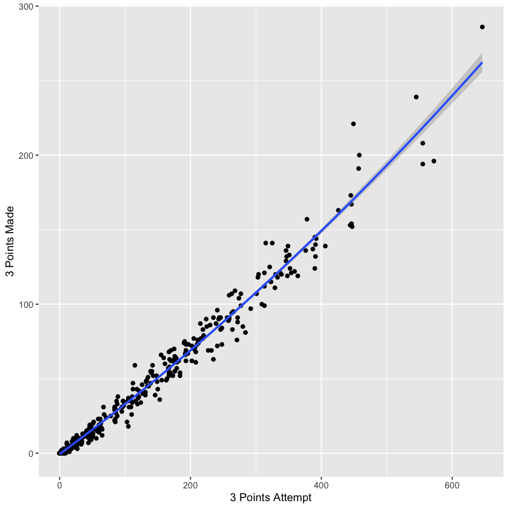

```r
ggplot(nba_stats, aes(x=nba_stats$X3PA, y=nba_stats$X3PM)) +
          geom_point() +
          stat_smooth(method='lm', formula = y ~ poly(x,2), size = 1) +
          xlab('3 Points Attempt') +
          ylab('3 Points Made')
```